# Project: The Movie Database

- Introduction
- Data Wrangling
- Exploratory Data Analysis
- Conclusions

## Introduction

### Dataset Description

> This data set contains information about 10,000 movies collected from the Movie Database (TMDb), including user ratings and revenue. I analyzed the dataset based on the questions below.

### Question(s) for Analysis

The following questions were used to analyze the Movie dataset:

- Which year has the highest number of movie released in the last 20 years in dataset?
- Which year has the highest or lowest movie budget in the last 20 years?
- Which year has the highest or lowest movie revenue in the last 20 years?
- Which movie has the highest or lowest votes?
- How many movie titles are above the 75th percentile revenues in 2015?

```python
# I imported necessary packages to efficiently explore the dataset
import numpy as np
import pandas as pd
import matplotlib.pyplot as plt
import seaborn as sns
sns.set_style('darkgrid')
% matplotlib inline
```

```python
# Pandas was upgraded to use dataframe.explode() function.
#!pip install --upgrade pandas==0.25.0
```

## Data Wrangling

> **Activity**: Here the structure of the dataset was determined to reveal the row and column features, shape, datatype, null or empty values and duplicate rows. The overall descriptive statistics were not left out. Thereafter the dataset was cleaned based on the problems realized when assessing the dataset properties.

### General Properties

> **Activity**: The structure of dataset was determined to understand the properties, reveal errors and identify problems in the dataset.

```python
# I loaded the dataset
df_tmdb = pd.read_csv('tmdb-movies.csv')

# First five rows of dataset is displayed
df_tmdb.head(5)
```

|  | id | imdb_id | popularity | budget | revenue | original_title | cast | homepage | director | tagline | ... | overview | runtime | genres | production_companies | release_date | vote_count | vote_average | release_year | budget_adj | revenue_adj |
| --- | --- | --- | --- | --- | --- | --- | --- | --- | --- | --- | --- | --- | --- | --- | --- | --- | --- | --- | --- | --- | --- |
| 0 | 135397 | tt0369610 | 32.985763 | 150000000 | 1513528810 | Jurassic World | Chris Pratt\|Bryce Dallas Howard\|Irrfan Khan\|Vi... | http://www.jurassicworld.com/ | Colin Trevorrow | The park is open. | ... | Twenty-two years after the events of Jurassic ... | 124 | Action\|Adventure\|Science Fiction\|Thriller | Universal Studios\|Amblin Entertainment\|Legenda... | 6/9/15 | 5562 | 6.5 | 2015 | 1.379999e+08 | 1.392446e+09 |
| 1 | 76341 | tt1392190 | 28.419936 | 150000000 | 378436354 | Mad Max: Fury Road | Tom Hardy\|Charlize Theron\|Hugh Keays-Byrne\|Nic... | http://www.madmaxmovie.com/ | George Miller | What a Lovely Day. | ... | An apocalyptic story set in the furthest reach... | 120 | Action\|Adventure\|Science Fiction\|Thriller | Village Roadshow Pictures\|Kennedy Miller Produ... | 5/13/15 | 6185 | 7.1 | 2015 | 1.379999e+08 | 3.481613e+08 |
| 2 | 262500 | tt2908446 | 13.112507 | 110000000 | 295238201 | Insurgent | Shailene Woodley\|Theo James\|Kate Winslet\|Ansel... | http://www.thedivergentseries.movie/#insurgent | Robert Schwentke | One Choice Can Destroy You | ... | Beatrice Prior must confront her inner demons ... | 119 | Adventure\|Science Fiction\|Thriller | Summit Entertainment\|Mandeville Films\|Red Wago... | 3/18/15 | 2480 | 6.3 | 2015 | 1.012000e+08 | 2.716190e+08 |
| 3 | 140607 | tt2488496 | 11.173104 | 200000000 | 2068178225 | Star Wars: The Force Awakens | Harrison Ford\|Mark Hamill\|Carrie Fisher\|Adam D... | http://www.starwars.com/films/star-wars-episod... | J.J. Abrams | Every generation has a story. | ... | Thirty years after defeating the Galactic Empi... | 136 | Action\|Adventure\|Science Fiction\|Fantasy | Lucasfilm\|Truenorth Productions\|Bad Robot | 12/15/15 | 5292 | 7.5 | 2015 | 1.839999e+08 | 1.902723e+09 |
| 4 | 168259 | tt2820852 | 9.335014 | 190000000 | 1506249360 | Furious 7 | Vin Diesel\|Paul Walker\|Jason Statham\|Michelle ... | http://www.furious7.com/ | James Wan | Vengeance Hits Home | ... | Deckard Shaw seeks revenge against Dominic Tor... | 137 | Action\|Crime\|Thriller | Universal Pictures\|Original Film\|Media Rights ... | 4/1/15 | 2947 | 7.3 | 2015 | 1.747999e+08 | 1.385749e+09 |

5 rows × 21 columns

```python
# Checked the number of columns and rows in the dataset
df_tmdb.shape
```

```
(10866, 21)
```

```python
#General descriptive statistic for the dataset are shown with dataframe.describe()
df_tmdb.describe()
```

|  | id | popularity | budget | revenue | runtime | vote_count | vote_average | release_year | budget_adj | revenue_adj |
| --- | --- | --- | --- | --- | --- | --- | --- | --- | --- | --- |
| count | 10866.000000 | 10866.000000 | 1.086600e+04 | 1.086600e+04 | 10866.000000 | 10866.000000 | 10866.000000 | 10866.000000 | 1.086600e+04 | 1.086600e+04 |
| mean | 66064.177434 | 0.646441 | 1.462570e+07 | 3.982332e+07 | 102.070863 | 217.389748 | 5.974922 | 2001.322658 | 1.755104e+07 | 5.136436e+07 |
| std | 92130.136561 | 1.000185 | 3.091321e+07 | 1.170035e+08 | 31.381405 | 575.619058 | 0.935142 | 12.812941 | 3.430616e+07 | 1.446325e+08 |
| min | 5.000000 | 0.000065 | 0.000000e+00 | 0.000000e+00 | 0.000000 | 10.000000 | 1.500000 | 1960.000000 | 0.000000e+00 | 0.000000e+00 |
| 25% | 10596.250000 | 0.207583 | 0.000000e+00 | 0.000000e+00 | 90.000000 | 17.000000 | 5.400000 | 1995.000000 | 0.000000e+00 | 0.000000e+00 |
| 50% | 20669.000000 | 0.383856 | 0.000000e+00 | 0.000000e+00 | 99.000000 | 38.000000 | 6.000000 | 2006.000000 | 0.000000e+00 | 0.000000e+00 |
| 75% | 75610.000000 | 0.713817 | 1.500000e+07 | 2.400000e+07 | 111.000000 | 145.750000 | 6.600000 | 2011.000000 | 2.085325e+07 | 3.369710e+07 |
| max | 417859.000000 | 32.985763 | 4.250000e+08 | 2.781506e+09 | 900.000000 | 9767.000000 | 9.200000 | 2015.000000 | 4.250000e+08 | 2.827124e+09 |

```python
#Display of columns' value details showing number and datatype of entries in each field with dataframe.info()
df_tmdb.info()
```

```
<class 'pandas.core.frame.DataFrame'>
RangeIndex: 10866 entries, 0 to 10865
Data columns (total 21 columns):
id                      10866 non-null int64
imdb_id                 10856 non-null object
popularity              10866 non-null float64
budget                  10866 non-null int64
revenue                 10866 non-null int64
original_title          10866 non-null object
cast                    10790 non-null object
homepage                2936 non-null object
director                10822 non-null object
tagline                 8042 non-null object
keywords                9373 non-null object
overview                10862 non-null object
runtime                 10866 non-null int64
genres                  10843 non-null object
production_companies    9836 non-null object
release_date            10866 non-null object
vote_count              10866 non-null int64
vote_average            10866 non-null float64
release_year            10866 non-null int64
budget_adj              10866 non-null float64
revenue_adj             10866 non-null float64
dtypes: float64(4), int64(6), object(11)
memory usage: 1.7+ MB
```

```python
# Datatypes of each column are confirmed
df_tmdb.dtypes
```

```
id                        int64
imdb_id                  object
popularity              float64
budget                    int64
revenue                   int64
original_title           object
cast                     object
homepage                 object
director                 object
tagline                  object
keywords                 object
overview                 object
runtime                   int64
genres                   object
production_companies     object
release_date             object
vote_count                int64
vote_average            float64
release_year              int64
budget_adj              float64
revenue_adj             float64
dtype: object
```

```python
# Number of unique values in each column were displayed with nunique function
df_tmdb.nunique()
```

```
id                      10865
imdb_id                 10855
popularity              10814
budget                    557
revenue                  4702
original_title          10571
cast                    10719
homepage                 2896
director                 5067
tagline                  7997
keywords                 8804
overview                10847
runtime                   247
genres                   2039
production_companies     7445
release_date             5909
vote_count               1289
vote_average               72
release_year               56
budget_adj               2614
revenue_adj              4840
dtype: int64
```

```python
# Presence of null values in each column were determined with dataframe.isnull()
df_tmdb.isnull().head()
```

|  | id | imdb_id | popularity | budget | revenue | original_title | cast | homepage | director | tagline | ... | overview | runtime | genres | production_companies | release_date | vote_count | vote_average | release_year | budget_adj | revenue_adj |
| --- | --- | --- | --- | --- | --- | --- | --- | --- | --- | --- | --- | --- | --- | --- | --- | --- | --- | --- | --- | --- | --- |
| 0 | False | False | False | False | False | False | False | False | False | False | ... | False | False | False | False | False | False | False | False | False | False |
| 1 | False | False | False | False | False | False | False | False | False | False | ... | False | False | False | False | False | False | False | False | False | False |
| 2 | False | False | False | False | False | False | False | False | False | False | ... | False | False | False | False | False | False | False | False | False | False |
| 3 | False | False | False | False | False | False | False | False | False | False | ... | False | False | False | False | False | False | False | False | False | False |
| 4 | False | False | False | False | False | False | False | False | False | False | ... | False | False | False | False | False | False | False | False | False | False |

5 rows × 21 columns

```python
# Sum total of null values in each column were detected combining isnull function with the numpy sum function
df_tmdb.isnull().sum()
```

```
id                         0
imdb_id                   10
popularity                 0
budget                     0
revenue                    0
original_title             0
cast                      76
homepage                7930
director                  44
tagline                 2824
keywords                1493
overview                   4
runtime                    0
genres                    23
production_companies    1030
release_date               0
vote_count                 0
vote_average               0
release_year               0
budget_adj                 0
revenue_adj                0
dtype: int64
```

```python
# Total sum of duplicate rows were determined.
sum(df_tmdb.duplicated())
```

```
1
```

Summarily, the dataframe (df_tmdb) contains precisely **10,866** rows and **21** columns. It is both messy and dirty due to the following:

- The release_date column datatype is string instead of datetime.
- There were missing values in some of the columns.
- There is one duplicate row in the dataset.

### Data Cleaning

> **Activity**: Here, the observations made in the introductory part of the investigation while assessing the dataframe will be addressed

#### Duplicate rows

```python
# Duplicate row was dropped.
df_tmdb.drop_duplicates(inplace=True)
```

```python
#Change was confirmed
df_tmdb.duplicated().sum()
```

```
0
```

Duplicated row was dropped and confirmed as a process of cleaning up the dateframe. There should be **10,865** rows having dropped the duplicate row. Now the data structural integrity is better. Change is confirmed below. The datatype error was corrected next.

```python
# To confirm changes
df_tmdb.shape
```

```
(10865, 21)
```

#### Incorrect datatype

```python
# Datatype of 'release_date' was changed from string to datetime
df_tmdb['release_date'] = pd.to_datetime(df_tmdb['release_date'])
```

```python
# To confirm changes
df_tmdb['release_date'].head(1)
```

```
0   2015-06-09
Name: release_date, dtype: datetime64[ns]
```

The column, release_date has been changed from **string** to **datetime** datatype. Next is to clean more integral structural errors such as missing values in columns.

#### Missing values and Unnecessary columns.

```python
#Missing values were dropped along with unnecessary columns.
df_tmdb_edited=df_tmdb.drop(['imdb_id','cast','homepage','director','genres','tagline','keywords','overview','production_companies'], axis=1)
```

```python
#confirm changes
df_tmdb_edited.shape # 12 columns should remain out of 21 original columns
```

```
(10865, 12)
```

```python
#  New dataset displayed
df_tmdb_edited.head(5)
```

|  | id | popularity | budget | revenue | original_title | runtime | release_date | vote_count | vote_average | release_year | budget_adj | revenue_adj |
| --- | --- | --- | --- | --- | --- | --- | --- | --- | --- | --- | --- | --- |
| 0 | 135397 | 32.985763 | 150000000 | 1513528810 | Jurassic World | 124 | 2015-06-09 | 5562 | 6.5 | 2015 | 1.379999e+08 | 1.392446e+09 |
| 1 | 76341 | 28.419936 | 150000000 | 378436354 | Mad Max: Fury Road | 120 | 2015-05-13 | 6185 | 7.1 | 2015 | 1.379999e+08 | 3.481613e+08 |
| 2 | 262500 | 13.112507 | 110000000 | 295238201 | Insurgent | 119 | 2015-03-18 | 2480 | 6.3 | 2015 | 1.012000e+08 | 2.716190e+08 |
| 3 | 140607 | 11.173104 | 200000000 | 2068178225 | Star Wars: The Force Awakens | 136 | 2015-12-15 | 5292 | 7.5 | 2015 | 1.839999e+08 | 1.902723e+09 |
| 4 | 168259 | 9.335014 | 190000000 | 1506249360 | Furious 7 | 137 | 2015-04-01 | 2947 | 7.3 | 2015 | 1.747999e+08 | 1.385749e+09 |

```python
# Dataframe tidiness is checked
df_tmdb_edited.info()
```

```
<class 'pandas.core.frame.DataFrame'>
Int64Index: 10865 entries, 0 to 10865
Data columns (total 12 columns):
id                10865 non-null int64
popularity        10865 non-null float64
budget            10865 non-null int64
revenue           10865 non-null int64
original_title    10865 non-null object
runtime           10865 non-null int64
release_date      10865 non-null datetime64[ns]
vote_count        10865 non-null int64
vote_average      10865 non-null float64
release_year      10865 non-null int64
budget_adj        10865 non-null float64
revenue_adj       10865 non-null float64
dtypes: datetime64[ns](1), float64(4), int64(6), object(1)
memory usage: 1.1+ MB
```

## Exploratory Data Analysis

> **Activity**:Investigation questions were attended to in this section. Dataset was explored to draw out insights, inferences and conclusions which can be pivotal to better decision making.

#### General Dataset Inspection

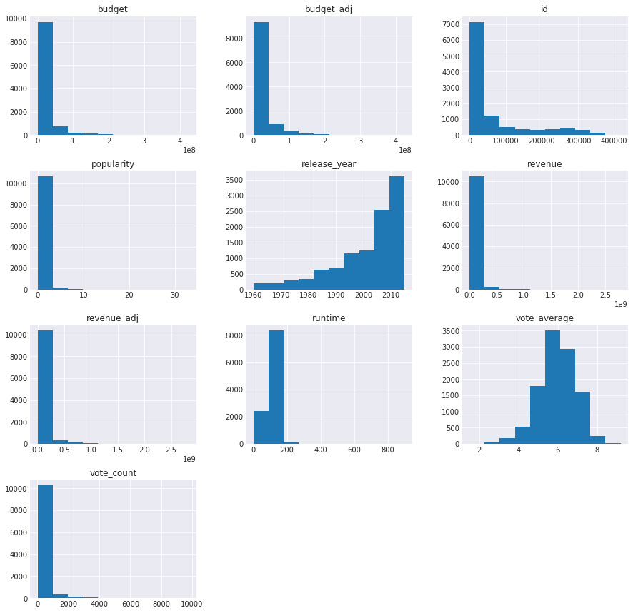

```python
# The distribution of data in the columns were assessed with histogram chart
df_tmdb_edited.hist(figsize=(15,15));
```

From the histogram charts, it was observed that budget, revenue, popularity and vote_count are right skewed, while release_year is left skewed and vote_average seem to be normal. It can be deduced generally that revenue, budget, popularity and vote_count individual distributions are alike and might have some relationship and impact on movie production every year.

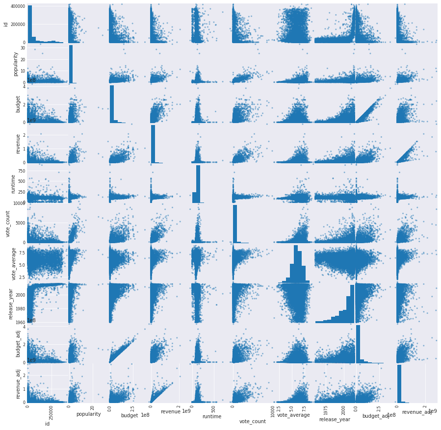

```python
#The relationship accross the columns were accessed using scatter_matrix function.
pd.plotting.scatter_matrix(df_tmdb_edited, figsize = (15,15));
```

### Which year has the highest number of movie released in the last 20 years in dataset?

```python
# Dataframe querried for last 20 years (1996 to 2015).
last_20_years= df_tmdb_edited.query('release_year >= 1996')

# The count of orginal_title(movie) was grouped by release_year to get the number of movies released per year.
last_20_years.groupby('release_year')['original_title'].count()
```

```
release_year
1996    204
1997    192
1998    210
1999    224
2000    227
2001    242
2002    266
2003    281
2004    307
2005    364
2006    408
2007    438
2008    496
2009    533
2010    489
2011    540
2012    588
2013    659
2014    700
2015    629
Name: original_title, dtype: int64
```

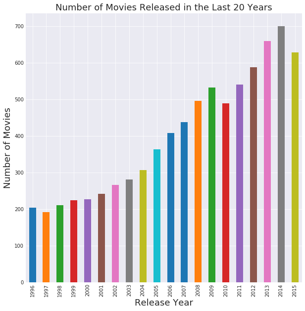

```python
#Yearly original title (movie) count derived to obtain number of movies released yearly
bar_height=last_20_years.groupby('release_year')['original_title'].count()

#Function defined subsequent plotting of similar bar charts
def bar_chart(bar_height):
    return bar_height.plot(kind='bar', figsize=(10,10))

#Function called to plot graph
bar_chart(bar_height)
plt.title('Number of Movies Released in the Last 20 Years',fontsize=18)
plt.ylabel('Number of Movies', fontsize=18)
plt.xlabel("Release Year", fontsize=18);
```

According to the bar chart above it can be deduced that the number of movies released increased across the years. The highest number of movies were released in year **2014**. But what could be responsible for this hike in movie release and does it translate to higher revenue?

### Which year has the highest or lowest movie budget in the last 20 years?

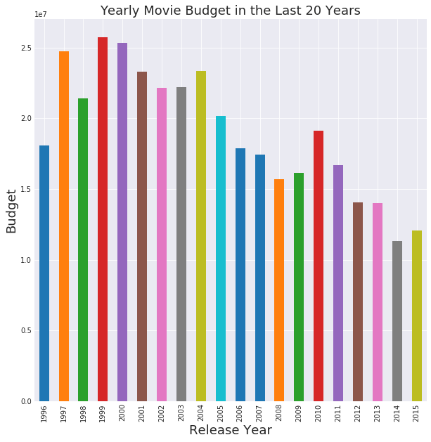

```python
#Mean budget for each year assigned to x
bar_height=last_20_years.groupby('release_year')['budget'].mean()
bar_chart(bar_height)

#Bar chart plotted to see relationship
plt.title('Yearly Movie Budget in the Last 20 Years',fontsize=18)
plt.ylabel('Budget', fontsize=18)
plt.xlabel("Release Year", fontsize=18);
```

> Number of movies released each year is not a column in the dataframe but can be listed out from `last_20_years.groupby('release_year')['original_title'].count()`in previous question and assigned to `number_movies_released` This was plotted against corresponding yearly average budget assigned to `Average_budget_per_year` in a scatter graph to determine relationship.

```python
# List of number of movies released in the last 20 years was determined and assigned to name
number_movies_released=last_20_years.groupby('release_year')['original_title'].count().values

#List displayed
number_movies_released
```

```
array([204, 192, 210, 224, 227, 242, 266, 281, 307, 364, 408, 438, 496,
       533, 489, 540, 588, 659, 700, 629])
```

```python
# List of number of average budget for movies in the last 20 years was determined and assigned to name
Average_budget_per_year=last_20_years.groupby('release_year')['budget'].mean().values

#List displayed
Average_budget_per_year
```

```
array([ 18073735.54411765,  24745243.09895833,  21426952.38095238,
        25737656.72321429,  25342290.74889868,  23313818.18181818,
        22160301.71052632,  22205899.26690391,  23356157.07491857,
        20173858.10164835,  17907316.91176471,  17432805.94520548,
        15688029.42943548,  16123985.0956848 ,  19130881.40286298,
        16700284.54074074,  14071571.5170068 ,  14015232.71775417,
        11319985.91142857,  12077182.12559618])
```

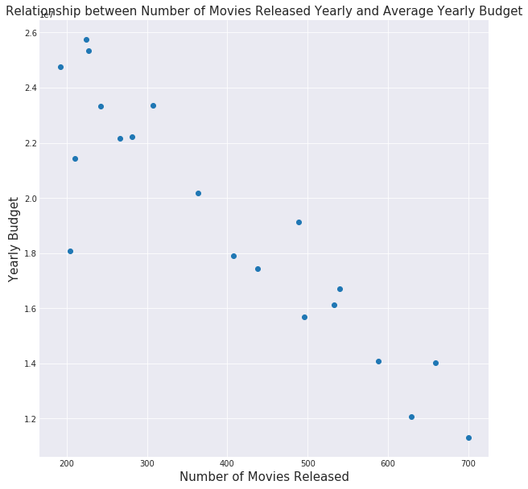

```python
#Scatter graph plotted
plt_s = plt.figure()
plt_s.set_figheight(10)
plt_s.set_figwidth(10)
plt.scatter(number_movies_released, Average_budget_per_year);
plt.title('Relationship between Number of Movies Released Yearly and Average Yearly Budget',fontsize=15)
plt.ylabel('Yearly Budget', fontsize=15)
plt.xlabel("Number of Movies Released", fontsize=15);
```

The scatter graph above showed that there is negative correlation between number of movie released and average budget each year. Would realized revenue from movies have same relationship with number of movies released?

### Which year has the highest or lowest movie revenue in the last 20 years?

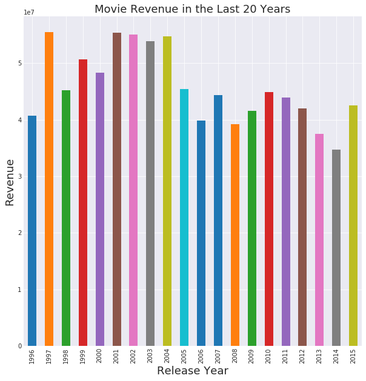

```python
#Yearly mean revenue derived.
bar_height=last_20_years.groupby('release_year')['revenue'].mean()

#Bar chart plotted with function
bar_chart(bar_height)
plt.title('Movie Revenue in the Last 20 Years',fontsize=18)
plt.ylabel('Revenue', fontsize=18)
plt.xlabel("Release Year", fontsize=18);
```

```python
last_20_years.groupby('release_year')['revenue'].mean()
```

```
release_year
1996    4.074261e+07
1997    5.549569e+07
1998    4.520559e+07
1999    5.069515e+07
2000    4.836432e+07
2001    5.541357e+07
2002    5.505120e+07
2003    5.387275e+07
2004    5.470301e+07
2005    4.537592e+07
2006    3.989152e+07
2007    4.431888e+07
2008    3.917680e+07
2009    4.161383e+07
2010    4.490599e+07
2011    4.388073e+07
2012    4.195311e+07
2013    3.748654e+07
2014    3.475879e+07
2015    4.254762e+07
Name: revenue, dtype: float64
```

Year **2014** had the lowest revenue in the last 20 years and year **1997**had the highest revenue.

```python
#list of average revenue per year in the last 20 years assigned to name
Average_revenue_per_year = last_20_years.groupby('release_year')['revenue'].mean().values
```

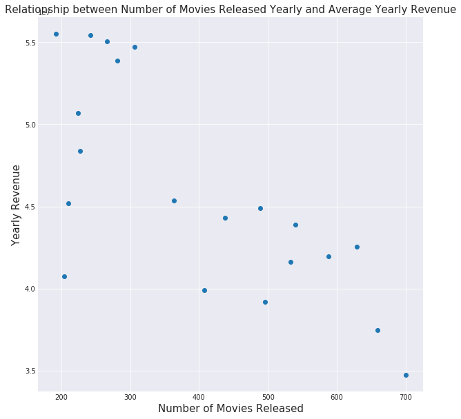

```python
#Scatter graph plotted
plt_s = plt.figure()
plt_s.set_figheight(10)
plt_s.set_figwidth(10)
plt.scatter(number_movies_released, Average_revenue_per_year);
plt.title('Relationship between Number of Movies Released Yearly and Average Yearly Revenue',fontsize=15)
plt.ylabel('Yearly Revenue', fontsize=15)
plt.xlabel("Number of Movies Released", fontsize=15);
```

The scatter graph above showed that there is negative correlation between number of movie released and average revenue each year.

### Which movie has the highest or lowest votes?

```python
#The mean vote_count on movies was grouped by original_title and converted to datafroame
movie_vote = df_tmdb_edited.groupby('original_title')['vote_count'].mean()
df_vote = pd.DataFrame(movie_vote)
```

```python
#The max value of vote count was determined
df_vote.vote_count.max()
#The dataframe was querried to get the movie title with the highest vote
df_vote.query('vote_count == 9767.0')
```

| original_title | vote_count |
| --- | --- |
| Inception | 9767.0 |

```python
#The min value of vote count was determined
df_vote.vote_count.min()

#Query is done on the same dataframe to find movids with lowest vote
df_vote.query('vote_count == 10.0')
```

| original_title | vote_count |
| --- | --- |
| 100 Degrees Below Zero | 10.0 |
| 2009 ë¡œìŠ¤íŠ¸ë©”ëª¨ë¦¬ì¦ˆ | 10.0 |
| 600 kilos d'or pur | 10.0 |
| 9 Kisses | 10.0 |
| 96 Minutes | 10.0 |
| 9to5: Days in Porn | 10.0 |
| A Boy Named Charlie Brown | 10.0 |
| A Boyfriend for Christmas | 10.0 |
| A Bride for Christmas | 10.0 |
| A Haunting in Salem | 10.0 |
| A Hitman in London | 10.0 |
| A Perfect Ending | 10.0 |
| A Rage in Harlem | 10.0 |
| A Thin Line Between Love and Hate | 10.0 |
| A Wrinkle in Time | 10.0 |
| A Zed & Two Noughts | 10.0 |
| Absolute Beginners | 10.0 |
| Age of Tomorrow | 10.0 |
| Alaska | 10.0 |
| Alice Through the Looking Glass | 10.0 |
| All About Evil | 10.0 |
| All Stars | 10.0 |
| All for the Winner | 10.0 |
| Alpha and Omega 2: A Howl-iday Adventure | 10.0 |
| Amateur | 10.0 |
| American Grindhouse | 10.0 |
| American Ninja 5 | 10.0 |
| An Evening with Kevin Smith | 10.0 |
| Animals Are Beautiful People | 10.0 |
| AntikÃ¶rper | 10.0 |
| ... | ... |
| Unforgettable | 10.0 |
| Up! | 10.0 |
| Uprising | 10.0 |
| Validation | 10.0 |
| Viking: The Berserkers | 10.0 |
| Vokzal dlya Dvoikh | 10.0 |
| Waterloo | 10.0 |
| Weather Girl | 10.0 |
| Welcome Home, Roxy Carmichael | 10.0 |
| What Doesn't Kill You | 10.0 |
| Where in the World Is Osama Bin Laden? | 10.0 |
| White Nights | 10.0 |
| White Sands | 10.0 |
| Who's That Knocking at My Door | 10.0 |
| Wild Hearts Can't Be Broken | 10.0 |
| Winnie the Pooh: Springtime with Roo | 10.0 |
| Without a Paddle: Nature's Calling | 10.0 |
| Wonders of the Solar System | 10.0 |
| Wonders of the Universe | 10.0 |
| World Without End | 10.0 |
| Yours, Mine and Ours | 10.0 |
| Yu-Gi-Oh! 3D: Bonds Beyond Time | 10.0 |
| Zebra Lounge | 10.0 |
| Zero Charisma | 10.0 |
| Zwart Water | 10.0 |
| uwantme2killhim? | 10.0 |
| Î¤Î± Ï€Î±Î¹Î´Î¹Î¬ Ï„Î¿Ï… Î´Î¹Î±Î²ÏŒÎ»Î¿Ï… | 10.0 |
| ì§‘ìœ¼ë¡œ ê°€ëŠ” ê¸¸ | 10.0 |
| ì˜í˜•ì œ | 10.0 |
| í˜•ì‚¬ Duelist | 10.0 |

476 rows × 1 columns

According to the queries carried out above, The movie 'inception' has the highest number of vote(9767.0). While there were several movies that fell under the lowest number of vote (10.0).

### How many movie titles are above the 75th percentile revenues in 2015?

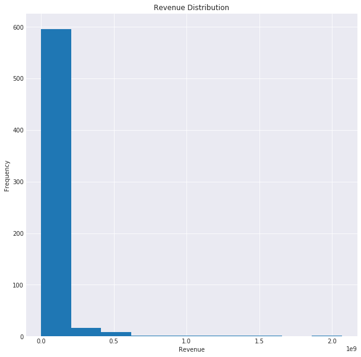

```python
# The dataframe was queried to focus on year 2015
film_release_2015 = df_tmdb_edited.query('release_year == 2015')

# A histograph was plotted to see the distribution of revenue in 2015
film_release_2015.revenue.plot(kind='hist', figsize=(10,10))
plt.xlabel('Revenue')
plt.ylabel("Frequency")
plt.title('Revenue Distribution');
```

This distribution indicates that data is right skewed and therefore more movies have revenues within the 25th percentile

```python
#The 75 percentile was gotten for 2015
np.percentile(film_release_2015['revenue'],75)

#The number of movies in the range above 75th percentile revenues was determined.
film_release_2015.query('revenue >= 3286448.0')['original_title'].count()
```

```
158
```

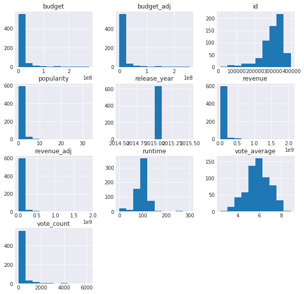

```python
# The distribution of data for 2015 in the columns were assessed with histogram chart
film_release_2015.hist(figsize=(10,10));
```

The general distribution of data in columns in 2015 resembles the distribution when all the years were considered especially the last 20 years. The same factors: `budget`, `vote_count`, `popularity` and `revenue` are interelated.

## Conclusions

> Summarily, a total of five questions were used to investigate the dataframe, The Movie Database. The investigation carriedout on the movies database revealed the following findings:
> - Year 2014 has the highest number of movies released in the last 20 years.
> - The year 2014 has the lowest movie budget, the highest being year 1999. An inverse relationship occurs between number of movies released yearly and budget.
> - The year 2014 has the lowest movie revenue, the highest being year 1997. An inverse relationship also exists between number of movies released yearly and revenue.
> - The movie title Inception has the highest vote count and about 476 movies share the lowest count.
> - It was gathered that 158 movie titles are above the 75th percentlile of revenue.

> **Limitation:**

> > The limitation of this dataframe is that there were columns that has missing values that are strings and cannot be augmented with measures of central tendency values like mean, median or mode. If the data were augmented, it would likely enhance the investigation and improve findings.

References were made to the websites below:

https://www.geeksforgeeks.org/how-to-plot-list-of-x-y-coordinates-in-matplotlib/

https://datatofish.com/dictionary-values-as-list/

```python
from subprocess import call
call(['python', '-m', 'nbconvert', 'Investigate_a_Dataset.ipynb'])
```

```
0
```